# Preparación de los datos

# Breve introducción a ggpairs

`ggpairs()` es una función de la librería GGally que permite crear matrices de gráficos y es realmente útil en la etapa de análisis y exploración de los datos. Pueden encontrar más información sobre `ggpairs()` y GGally en el siguiente enlace https://ggobi.github.io/ggally/#ggally

El siguiente ejemplo muestra el gráfico de las correlaciones y densidades de algunos atributos del dataset de ventas de casas.

```r
library(GGally)
```

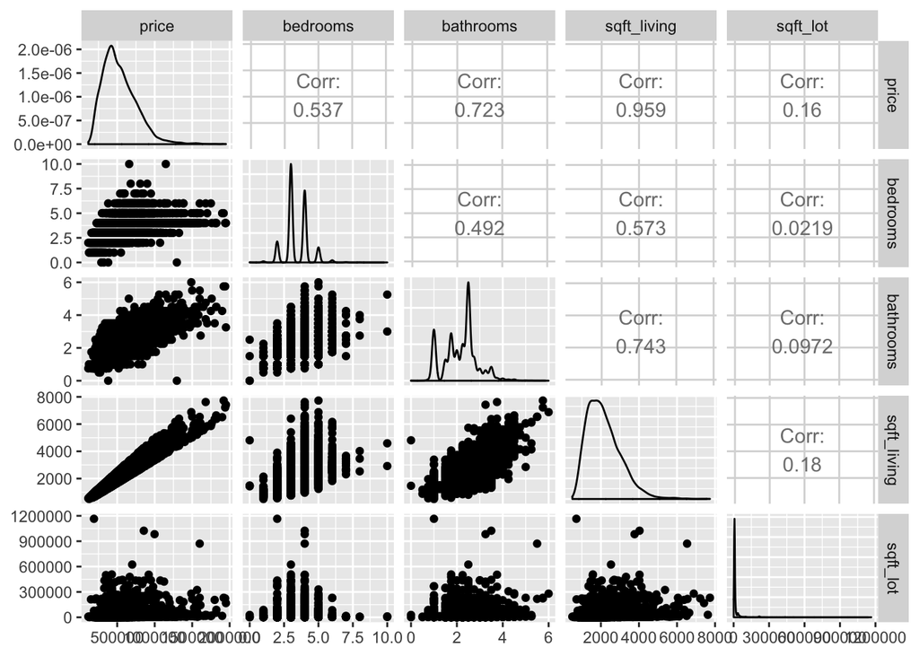

```r
library(ggplot2)

casas <- read.csv('kc_house_data.csv', header = T, na.strings = '?')
ggpairs(casas, columns = 3:7)
```

# Limpieza y transformación de los datos

A continuación utilizando el dataset de venta de casas veremos algunas funcionalidades de R para la transformación de datos.

### Detección de valores faltantes y transformaciones

La función `is.na` nos permite detectar los valores faltantes en un dataset.

El siguiente código muestra el número de elementos faltantes en todo un dataset

`sum(is.na(dataset))`

También podemos buscar valores faltantes en columnas especificas

`sum(is.na(dataset$columna))`

R posee funciones para modificar dataframes las cuales podemos aprovechar para el tratamiento de valores faltantes y transformaciones

Podemos asignar valores nuevos a toda una columna.

`dataframe$columna <- 0`

`dataframe$columna <- funcion(dataframe$columna)`

O podemos hacerlo solo en los campos faltantes.

`dataframe$columna[is.na(dataframe$columna)] <- 0`

`dataframe$columna[is.na(dataframe$columna)] <- funcion(dataframe$columna)`

# Ejercicios sobre transformaciones

### 1. Correción de valores inconsistentes

```r
casas$bathrooms[1:10]
```

```
##  [1] 2.25 1.00 4.50 1.50 1.00 1.75 2.00 3.00 2.00 1.75
```

Como podemos observar la columna bathrooms posee valores inconsistentes ya que no tiene sentido que una casa tenga 4.5 baños.

Modifique la columna bathrooms para que solo posea valores enteros

```r
# Se aplica ceiling para redondear debido a que se está suponiendo que para el redondeo cualquiera
# de las siguientes configuraciones de baño cuentan como un baño completo:
#
# baño con lavatorio o sanitario (1/4 o 0.25)
# baño con lavatorio y sanitario (1/2 o 0.5)
# baño con ducha, lavatorio y sanitario (3/4 o 0.75)
# baño con tina, ducha, lavatorio y sanitario (4/4 o 1)
#
# Por lo tanto se considera un valor de 1.5 (un baño completo y medio baño) como si fuesen 2 baños
# completos.
#
# Fuente: https://www.realtor.com/advice/sell/if-i-take-out-the-tub-does-a-bathroom-still-count-as-a-full-bath/
#
# Se crea una nueva variable llamada bathrooms_tidy con los valores limpios (esto com el fin de mantener
# la trazabilidad de los cambios).
casas$bathrooms_tidy <- ceiling(casas$bathrooms)

# Validación de la transformación de los valores de la variable.
casas$bathrooms_tidy[1:10]
```

```
##  [1] 3 1 5 2 1 2 2 3 2 2
```

### 2. Llevar los datos a distribución normal.

Modifique la columna price del dataset de precios de casas para que siga una distribución normal. Pista: utilice la función `log10`

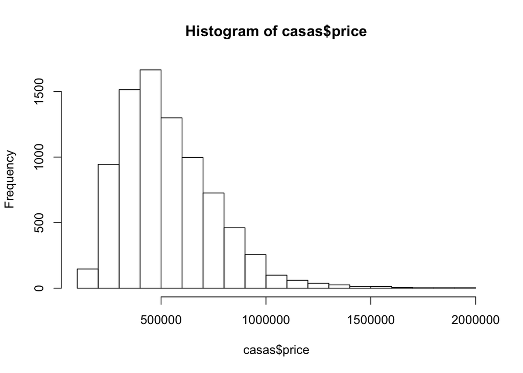

```r
# Precios antes de la modificación
hist(casas$price)
```

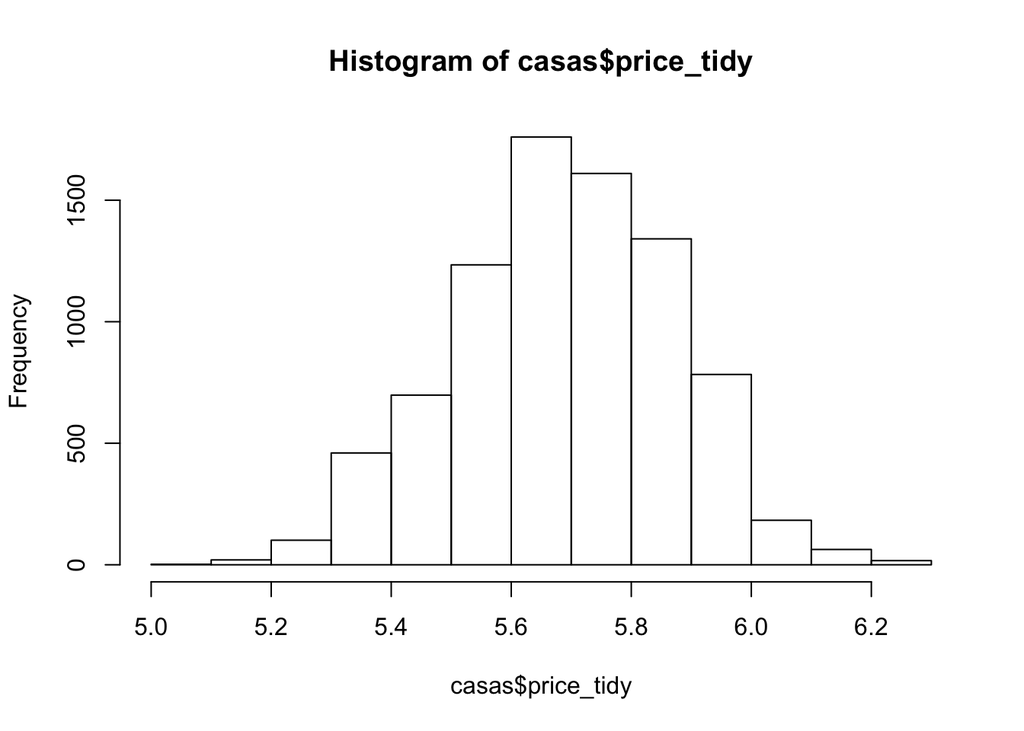

```r
# Transformación de los valores de la variable price usando log10.
#
# Se crea una nueva variable llamada price_tidy con los valores transformados (esto com el fin de mantener
# la trazabilidad de los cambios).
casas$price_tidy <- log10(casas$price)

# Precios normalmente distribuidos
hist(casas$price_tidy)
```

Note que ahora los precios ya no se agrupan a la izquierda.

### 3. Imputar datos faltantes

Reemplace los valores faltantes de la columna sqft_living con la mediana de los valores de esa columna. Pista use la función `median`.

Nota: este dataset no posee valores faltantes pero para efectos del ejercicio esto no nos afecta ya que el código sería igual.

```r
# Cálculo de valor de la mediana para la variable sqft_living.
sqft_living_median <- median(casas$sqft_living, na.rm = TRUE)

# Se obtiene un vector booleano con los valores NA dentro de la variable sqft_living.
sqft_living_isna <- is.na(casas$sqft_living)

# Duplicación de los valores de la variable sqft_living como la nueva variable sqft_living_tidy.
#
# Se crea una nueva variable llamada sqft_living_tidy (esto com el fin de mantener la trazabilidad
# de los cambios).
casas$sqft_living_tidy <- casas$sqft_living

# Transformación de los valores NA de la variable sqft_living en el dataframe casas.
casas$sqft_living_tidy[sqft_living_isna] <- sqft_living_median

# Validación de la transformación de los valores de la variable.
sum(is.na(casas$sqft_living_tidy))
```

```
## [1] 0
```

### 4. Escalado

Un proceso común en esta etapa es escalar los atributos para que los valores queden en el rango de 0-1.

La siguiente función realiza el escalado de valores

```r
feature_scaling <- function(x) {
  x_escalado <- ((x - min(x)) / (max(x) - min(x)))
  return(x_escalado)
}
```

1. Utilice la función `feature_scaling` para escalar los valores de la columna sqft_lot
2. Compare el resultado con la función `scale()`

```r
# Transformación de la variable sqft_lot utilizando la función feature_scaling.
#
# Se crea una nueva variables llamada sqft_lot_feature_scaled (esto com el fin de mantener la trazabilidad
# de los cambios).
casas$sqft_lot_feature_scaled <- feature_scaling(casas$sqft_lot)

# Transformación de la variable sqft_lot utilizando la función scale.
#
# Se crea una nueva variable llamada sqft_lot_scaled (esto com el fin de mantener la trazabilidad
# de los cambios).
casas$sqft_lot_scaled <- scale(casas$sqft_lot)[,1]

# Comparación de ambas funciones de escalamiento de atributos.
#
# La función feature_scaling emplea la normalización min-max.
head(casas$sqft_lot_feature_scaled)
```

```
## [1] 0.005773555 0.008142413 0.087101490 0.007894190 0.016646425 0.007867564
```

```r
# La función scale emplea la normalización z-score
# (en el siguiente bloque de código se observa este comportamiento usando la función z_score).
#
# Fuente: https://en.wikipedia.org/wiki/Feature_scaling#Methods
#
head(casas$sqft_lot_scaled)
```

```
## [1] -0.2299812 -0.1688056  1.8703044 -0.1752160  0.0508096 -0.1759036
```

### 5. Normalización con la función z-score

Otra función utilizada para transformar atributos se llama z-score y consiste en restar la media de los datos y dividir por la desviación estandar.

Escriba la función z_score y utilicela sobre la columna bathrooms.

Pista: utilice las funciones `mean`, `sd`

```r
# Creación de la función z_score.
z_score <- function(x) {
  z_scored <- (x - mean(x)) / sd(x)

  return(z_scored)
}

# Como parte del ejercicio anterior aquí se observa el uso de la función z_score a la variable sqft_lot
# y como ambas variable sqft_lot_z_score y sqft_lot_scaled retornan los mismos valores.
#
# (Esto no es parte de esta pregunta, pero me pareció interesante hacer la validación).
casas$sqft_lot_z_score <- z_score(casas$sqft_lot)
head(casas$sqft_lot_z_score)
```

```
## [1] -0.2299812 -0.1688056  1.8703044 -0.1752160  0.0508096 -0.1759036
```

```r
head(casas$sqft_lot_scaled)
```

```
## [1] -0.2299812 -0.1688056  1.8703044 -0.1752160  0.0508096 -0.1759036
```

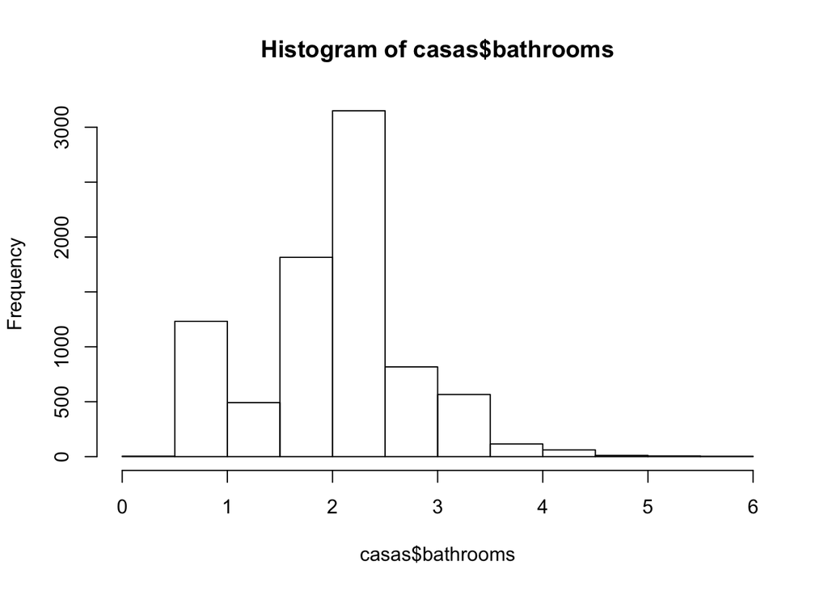

```r
# Datos antes de la transformación
hist(casas$bathrooms)
```

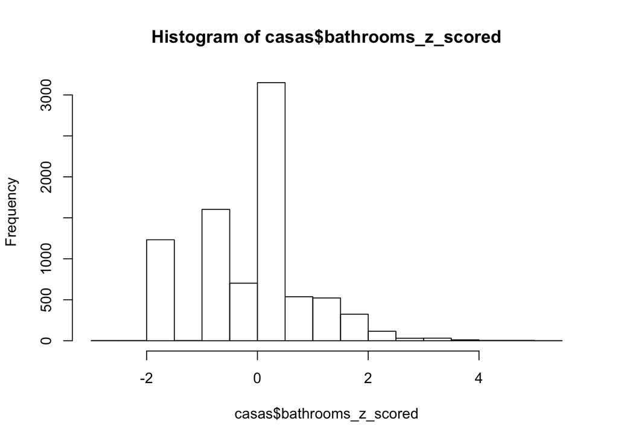

```r
# Transformación de los valores de bathrooms (transformación realizada previamente) utilizando la
# función z-score.
#
# Se crea una nueva variable llamada bathrooms_z_scored (esto com el fin de mantener la trazabilidad
# de los cambios).
casas$bathrooms_z_scored <- z_score(casas$bathrooms)

# Después de la transformación
hist(casas$bathrooms_z_scored)
```

Note que ahora la media de los datos se acerca a 0